# Genetic Algorithm Recommender

Matheus Schmitz  
[LinkedIn](https://www.linkedin.com/in/matheusschmitz/)  
[Github Portfolio](https://matheus-schmitz.github.io/)

### **Dataset: Fermentation Lab Experiment**

A CSV file containing empirical data for a fermentation lab experiment (e.g. yogurt).

The variables of each experiment are:

- **protein_quantity**: percent of the formula that is protein
- **starch_quantity**: percent of of formula that is starch
- **probiotic_quantity**: percent of formula that is probiotic
- **water_quantity**: percent of the formula that is water
- **starting_ph**: the pH of the mixture at the start of fermentation

The post-fermentation measurements of each experiment are:

- **fermentation_time**: how long it took to ferment the mixture (minutes)
- **coagulation_quality**: a quantification of texture of the post-fermented mixture

### Challenge

For this challenge, we want to leverage the fermentation lab experiment dataset to implement a function that can suggest optimal experimental parameters to yield desired output results. In other words, suggest what experiment a scientist would have to conduct in order for the experiment to yield a specific fermentation time and coagulation quality:

> suggest_experimental_parameters(  
> desired_fermentation_time=83,  
> desired_coagulation_quality=1.22)

> {  
> protein_quantity: 0.22,  
> starch_quantity: 0.41,  
> probiotic_quantity: 0.35  
> water_quantity: 0.16,  
> starting_ph: 6.3  
> } # just an example

Hint: How certain are you that the suggestions would yield the desired results? Is there more than one likely experiment that would yield the desired post-fermentation properties? Keep in mind the explanatory versus response variables of your model.

## Phase 1: Data Exploration

### Imports

```python
# Data Manipualtion
import numpy as np
import pandas as pd
pd.options.display.float_format = "{:,.3f}".format
from collections import defaultdict

# Auxilary
from tqdm import tqdm

# Plotting
import matplotlib.pyplot as plt
import seaborn as sns
%matplotlib inline

# Warnings
import warnings
warnings.filterwarnings('ignore')
```

### Load Data

```python
# Load Data
df = pd.read_csv('dataset_B.csv')

# Split
X = df.drop(columns=['fermentation_time', 'coagulation_quality'])
fermentation_time = df['fermentation_time']
coagulation_quality = df['coagulation_quality']
```

```python
df.info()
```

```
<class 'pandas.core.frame.DataFrame'>
RangeIndex: 98 entries, 0 to 97
Data columns (total 7 columns):
 #   Column               Non-Null Count  Dtype
---  ------               --------------  -----
 0   protein_quantity     98 non-null     float64
 1   starch_quantity      98 non-null     float64
 2   probiotic_quantity   98 non-null     float64
 3   water_quantity       98 non-null     float64
 4   starting_ph          98 non-null     float64
 5   fermentation_time    98 non-null     int64
 6   coagulation_quality  98 non-null     float64
dtypes: float64(6), int64(1)
memory usage: 5.5 KB
```

```python
df.head(3)
```

|  | protein_quantity | starch_quantity | probiotic_quantity | water_quantity | starting_ph | fermentation_time | coagulation_quality |
| --- | --- | --- | --- | --- | --- | --- | --- |
| 0 | 0.315 | 0.062 | 0.590 | 0.033 | 7.500 | 90 | 0.500 |
| 1 | 0.435 | 0.232 | 0.248 | 0.085 | 7.800 | 351 | 6.900 |
| 2 | 0.231 | 0.298 | 0.328 | 0.143 | 7.500 | 294 | 4.700 |

```python
# Are the inputs represented as percentages?
df[['protein_quantity', 'starch_quantity', 'probiotic_quantity', 'water_quantity']].sum(axis='columns').round(2).value_counts()
```

```
1.000    98
dtype: int64
```

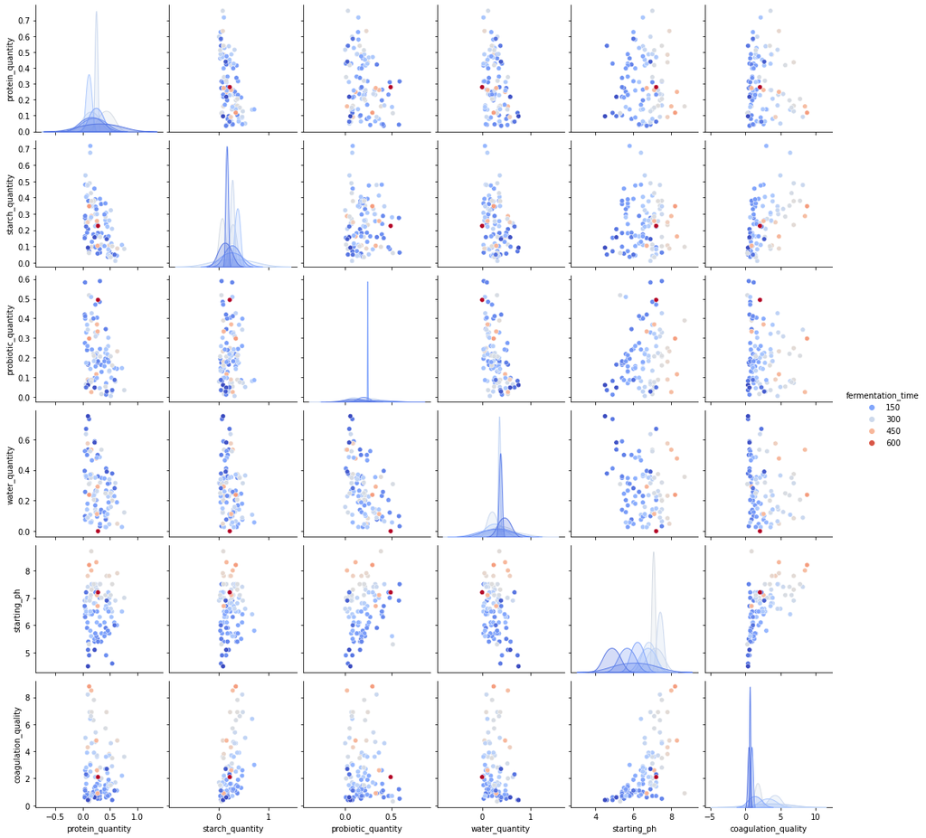

```python
# Correlations with fermentation_time
sns.pairplot(df, palette='coolwarm', hue='fermentation_time')
plt.show()
```

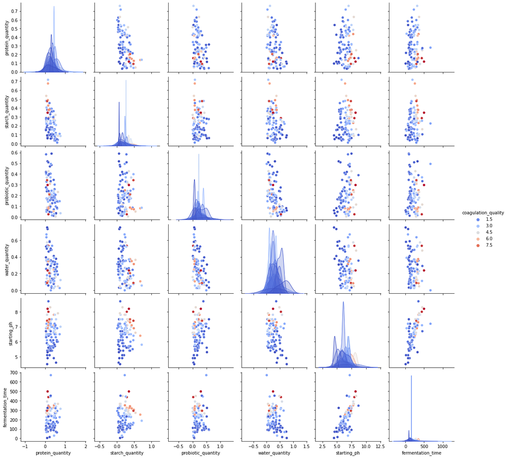

```python
# Correlations with coagulation_quality
sns.pairplot(df, palette='coolwarm', hue='coagulation_quality')
plt.show()
```

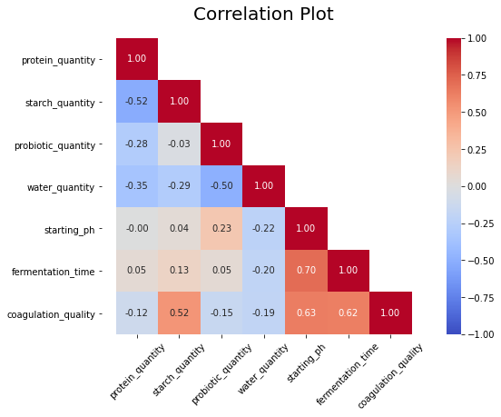

```python
fig, ax = plt.subplots(figsize=(8,6))
plt.title('Correlation Plot', size=20, pad=20)
mask = np.triu(df.corr())
mask[np.diag_indices_from(mask)] = False
sns.heatmap(df.corr(), mask=mask,
            cmap='coolwarm', vmin=-1, vmax=1,
            annot=True, fmt=".2f")
plt.xticks(rotation=45)
plt.axis('equal')
plt.show()
```

## Phase 2: Solution Design

### Imports

```python
# Data Manipualtion
import numpy as np
import pandas as pd
pd.options.display.float_format = "{:,.3f}".format
from collections import defaultdict

# Auxilary
from tqdm import tqdm

# Machine Learning
import sklearn
from sklearn.ensemble import GradientBoostingRegressor, RandomForestRegressor
from sklearn.model_selection import GridSearchCV, KFold
from sklearn.pipeline import Pipeline
from sklearn.preprocessing import MinMaxScaler
from sklearn.metrics import mean_squared_error

# Genetic Algorithm
import pygad
```

### Load Data

```python
# Load Data
df = pd.read_csv('dataset_B.csv')

# Split
X = df.drop(columns=['fermentation_time', 'coagulation_quality'])
fermentation_time = df['fermentation_time']
coagulation_quality = df['coagulation_quality']

# Scale data
mms = defaultdict(lambda: MinMaxScaler())
mms['X'].fit(X.drop(columns='starting_ph'))
mms['ph'].fit(X['starting_ph'].to_numpy().reshape(-1, 1))
mms['ft'].fit(fermentation_time.to_numpy().reshape(-1, 1))
mms['cq'].fit(coagulation_quality.to_numpy().reshape(-1, 1))
```

```
MinMaxScaler()
```

### Machine Learning

Models which learn to predict the properties resulting from a given set of experimental parameters.

They are used later on as part of the descriminator system, so that the members of each generation can be chosen based on how well they approximate the desired properties.

**Fermentation Time**

```python
%%time
# Pipeline to standardize then run the classifier
R_ft =  Pipeline([("scaler", MinMaxScaler()),
                  ("rf", GradientBoostingRegressor())])

# Grid with parameters to be tested via CV
R_ft_param_grid_ = {'rf__max_depth': [3, 4, 5, 6],
                    'rf__min_samples_leaf': [1, 2, 3, 4],
                    'rf__ccp_alpha': np.logspace(-3, 0, 4)}

# Instantiate GridSearchCV using accuracy as the scorer
R_ft_gridCV = GridSearchCV(R_ft, R_ft_param_grid_, cv=5, n_jobs=-1, scoring='neg_root_mean_squared_error')

# Run GridSearchCV
R_ft_gridCV = R_ft_gridCV.fit(X, fermentation_time.ravel())
```

```
Wall time: 16.7 s
```

```python
R_ft_gridCV.best_estimator_
```

```
Pipeline(steps=[('scaler', MinMaxScaler()),
                ('rf', GradientBoostingRegressor(ccp_alpha=0.01, max_depth=6))])
```

```python
R_ft_gridCV.best_score_
```

```
-87.37462382294984
```

**Coagulation Quality**

```python
%%time
# Pipeline to standardize then run the classifier
R_cq =  Pipeline([("scaler", MinMaxScaler()),
                  ("rf", GradientBoostingRegressor())])

# Grid with parameters to be tested via CV
R_cq_param_grid_ = {'rf__max_depth': [3, 4, 5, 6],
                    'rf__min_samples_leaf': [1, 2, 3, 4],
                    'rf__ccp_alpha': np.logspace(-3, 0, 4)}

# Instantiate GridSearchCV using accuracy as the scorer
R_cq_gridCV = GridSearchCV(R_cq, R_cq_param_grid_, cv=5, n_jobs=-1, scoring='neg_root_mean_squared_error')

# Run GridSearchCV
R_cq_gridCV = R_cq_gridCV.fit(X, coagulation_quality.ravel())
```

```
Wall time: 4.01 s
```

### Genetic Algorithm

Generator: Genetic Algorithm  
Discriminator: Fitness Function

We note that features 1-4 are percentages, and hence I apply a modification to the genetic algorithm so that it's mutations are all represented as relative changes to the percentages, such that the sum of those initial four features is always equals to one. This can be thought of as applying a Softmax activation to those features.

Additionally, since the classifier models are only trained to predict features on the range seen in the training data, I bound the possible features mutations within the Genetic Algorithm to be within the range seen for each feature at training time.

```python
def scale_genes(ga_obj):
    offspring_pct = ga_obj.population[:, :4]
    offspring_pct_sums = ga_obj.population[:, :4].sum(axis=1).reshape(-1, 1)
    scaled = offspring_pct / offspring_pct_sums
    ga_obj.population[:, :4] = scaled
```

```python
# Specify the range limit for each gene based on historic data
gene_range = []

min_values = df.min(axis='rows')[:5].to_numpy()
max_values = df.max(axis='rows')[:5].to_numpy()

for low, high in zip(min_values, max_values):
    gene_range.append({'low': low, 'high': high})
```